# 重賞レース予測レポート【レース終了】

作成日時: 2026/08/16 16:19:38

☞ [マニュアル(pdf)](https://ryutoro-galois.github.io/keiba-predictor/manual/manual.pdf)

☞ 過去6年の同一レース結果: [2025年](https://ryutoro-galois.github.io/keiba-predictor/report/PredResult_2025y_raceDate_20250816_20250817.html), [2024年](https://ryutoro-galois.github.io/keiba-predictor/report/PredResult_2024y_raceDate_20240811_20240811.html), [2023年](https://ryutoro-galois.github.io/keiba-predictor/report/PredResult_2023y_raceDate_20230813_20230813.html), [2022年](https://ryutoro-galois.github.io/keiba-predictor/report/PredResult_2022y_raceDate_20220814_20220814.html), [2021年](https://ryutoro-galois.github.io/keiba-predictor/report/PredResult_2021y_raceDate_20210815_20210815.html), [2020年](https://ryutoro-galois.github.io/keiba-predictor/report/PredResult_2020y_raceDate_20200816_20200816.html)

☞ 過去4週間の別レース結果: [1週前(8/8-9)](https://ryutoro-galois.github.io/keiba-predictor/report/PredResult_2026y_raceDate_20260808_20260809.html), [2週前(8/2)](https://ryutoro-galois.github.io/keiba-predictor/report/PredResult_2026y_raceDate_20260802_20260802.html), [3週前(7/26)](https://ryutoro-galois.github.io/keiba-predictor/report/PredResult_2026y_raceDate_20260726_20260726.html), [4週前(7/19)](https://ryutoro-galois.github.io/keiba-predictor/report/PredResult_2026y_raceDate_20260719_20260719.html)

☞ netkeiba: [新潟ジャンプステークス(JGⅢ)](https://race.netkeiba.com/race/result.html?race_id=202604020709&rf=race_submenu), [中京記念(GⅢ)](https://race.netkeiba.com/race/result.html?race_id=202607020807&rf=race_submenu), [札幌記念(GⅡ)](https://race.netkeiba.com/race/result.html?race_id=202601010811&rf=race_submenu)

☞ レース結果(csv): [8/15-16](https://ryutoro-galois.github.io/keiba-predictor/csv/race_result_20260815_20260816.csv)

## 【レース結果(1)】人気と着順の関係

### 【新潟ジャンプステークス(2026/08/15(土))】

【新潟ジャンプステークス(J.GⅢ)】  
2026/08/15(土), 04_新潟, 障芝外-内3250m

[interactive chart not shown]

### 【中京記念(2026/08/16(日))】

【中京記念(GⅢ)】  
2026/08/16(日), 07_中京, 芝左1600m

[interactive chart not shown]

### 【札幌記念(2026/08/16(日))】

【札幌記念(GⅡ)】  
2026/08/16(日), 01_札幌, 芝右2000m

[interactive chart not shown]

## 【レース結果(2)】コーナー通過順位

### 【新潟ジャンプステークス(2026/08/15(土))】

【新潟ジャンプステークス(J.GⅢ)】  
2026/08/15(土), 04_新潟, 障芝外-内3250m

[interactive chart not shown]

### 【中京記念(2026/08/16(日))】

【中京記念(GⅢ)】  
2026/08/16(日), 07_中京, 芝左1600m

[interactive chart not shown]

### 【札幌記念(2026/08/16(日))】

【札幌記念(GⅡ)】  
2026/08/16(日), 01_札幌, 芝右2000m

[interactive chart not shown]

## 0. 推し馬予測 (AI予測)

### 【新潟ジャンプステークス(J.GⅢ) 2026/08/15(土)】

- 本命(◎): 1-3着内確率(勝負強さ)が1位の馬
- 対抗(◯): 1-3着内確率が2-N位(20%程度以上)の中で予測タイムが最も速い馬
- 3番手(▲): 1-3着内確率が2-N位(20%程度以上)のでダークホース確率が最も高い馬
- 穴: ダークホース確率が上位1-M位(40%程度以上)の中で1-3着内確率が最も高い馬

| 推し馬 | 枠番 | 馬番 | 人気 | オッズ | 馬名 | 騎手 | 調教師 | 予測タイム(sec) | 1_順位 | 1-3着内確率(%) | 2_順位 | ﾀﾞｰｸﾎｰｽ確率(%) | 3_順位 |
| --- | --- | --- | --- | --- | --- | --- | --- | --- | --- | --- | --- | --- | --- |
| 本命(◎) | 1 | 1 | 2 | 4.1 | シャンデルナゴル | 中村将之 | 石坂公一 | 209.1 | 1.5 | 28.1 | 1 | 0.6 | 10 |
| 対抗(◯) | 4 | 4 | 4 | 5.3 | ブラックボイス | 坂口智康 | 浅利英明 | 216.3 | 3.0 | 27.0 | 2 | 0.6 | 9 |
| 3番手(▲) | 8 | 11 | 5 | 7.3 | ヴェールランス | 五十嵐雄祐 | 中舘英二 | 222.7 | 6.0 | 20.4 | 4 | 0.9 | 7 |
| 穴 | 7 | 9 | 6 | 8.6 | ピーターサイト | 上野翔 | 村田一誠 | 222.4 | 5.0 | 18.7 | 5 | 0.9 | 6 |

### 【中京記念(GⅢ) 2026/08/16(日)】

- 本命(◎): 1-3着内確率(勝負強さ)が1位の馬
- 対抗(◯): 1-3着内確率が2-N位(20%程度以上)の中で予測タイムが最も速い馬
- 3番手(▲): 1-3着内確率が2-N位(20%程度以上)のでダークホース確率が最も高い馬
- 穴: ダークホース確率が上位1-M位(40%程度以上)の中で1-3着内確率が最も高い馬

| 推し馬 | 枠番 | 馬番 | 人気 | オッズ | 馬名 | 騎手 | 調教師 | 予測タイム(sec) | 1_順位 | 1-3着内確率(%) | 2_順位 | ﾀﾞｰｸﾎｰｽ確率(%) | 3_順位 |
| --- | --- | --- | --- | --- | --- | --- | --- | --- | --- | --- | --- | --- | --- |
| 本命(◎) | 5 | 9 | 2 | 6.3 | リリージョワ | 浜中俊 | 武幸四郎 | 98.5 | 6 | 45.8 | 1 | 0.4 | 14 |
| 対抗(◯) | 6 | 12 | 1 | 3.5 | サトノシャイニング | Ｊ．コレット | 杉山晴紀 | 92.3 | 1 | 23.0 | 3 | 0.3 | 16 |
| 3番手(▲) | 6 | 11 | 6 | 14.5 | チェルビアット | 吉村誠之助 | 高野友和 | 97.6 | 5 | 20.9 | 4 | 1.2 | 11 |
| 穴 | 4 | 7 | 10 | 18.9 | カネラフィーナ | 石川裕紀人 | 手塚貴久 | 97.4 | 4 | 15.6 | 6 | 34.3 | 4 |

### 【札幌記念(GⅡ) 2026/08/16(日)】

- 本命(◎): 1-3着内確率(勝負強さ)が1位の馬
- 対抗(◯): 1-3着内確率が2-N位(20%程度以上)の中で予測タイムが最も速い馬
- 3番手(▲): 1-3着内確率が2-N位(20%程度以上)のでダークホース確率が最も高い馬
- 穴: ダークホース確率が上位1-M位(40%程度以上)の中で1-3着内確率が最も高い馬

| 推し馬 | 枠番 | 馬番 | 人気 | オッズ | 馬名 | 騎手 | 調教師 | 予測タイム(sec) | 1_順位 | 1-3着内確率(%) | 2_順位 | ﾀﾞｰｸﾎｰｽ確率(%) | 3_順位 |
| --- | --- | --- | --- | --- | --- | --- | --- | --- | --- | --- | --- | --- | --- |
| 本命(◎) | 4 | 7 | 1 | 3.9 | ショウヘイ | 川田将雅 | 友道康夫 | 118.7 | 2 | 24.4 | 1 | 0.6 | 15 |
| 対抗(◯) | 2 | 4 | 4 | 7.7 | マジックサンズ | 横山和生 | 須貝尚介 | 130.5 | 9 | 24.2 | 2 | 0.6 | 14 |
| 穴 | 3 | 6 | 9 | 17.3 | ローシャムパーク | 池添謙一 | 田中博康 | 118.7 | 2 | 18.5 | 5 | 60.8 | 2 |

## 1. 予測チャート (タイム/勝負強さ)

### 【新潟ジャンプステークス(J.GⅢ)】

2026/08/15(土), 04_新潟, 障芝外-内3250m

[interactive chart not shown]

### 【中京記念(GⅢ)】

2026/08/16(日), 07_中京, 芝左1600m

[interactive chart not shown]

### 【札幌記念(GⅡ)】

2026/08/16(日), 01_札幌, 芝右2000m

[interactive chart not shown]

## 2. オッズモニタリング (毎時)

### 【新潟ジャンプステークス】

[interactive chart not shown]

### 【中京記念】

[interactive chart not shown]

### 【札幌記念】

[interactive chart not shown]

## 3. 出馬表

### 【新潟ジャンプステークス 2026/08/15(土) 】

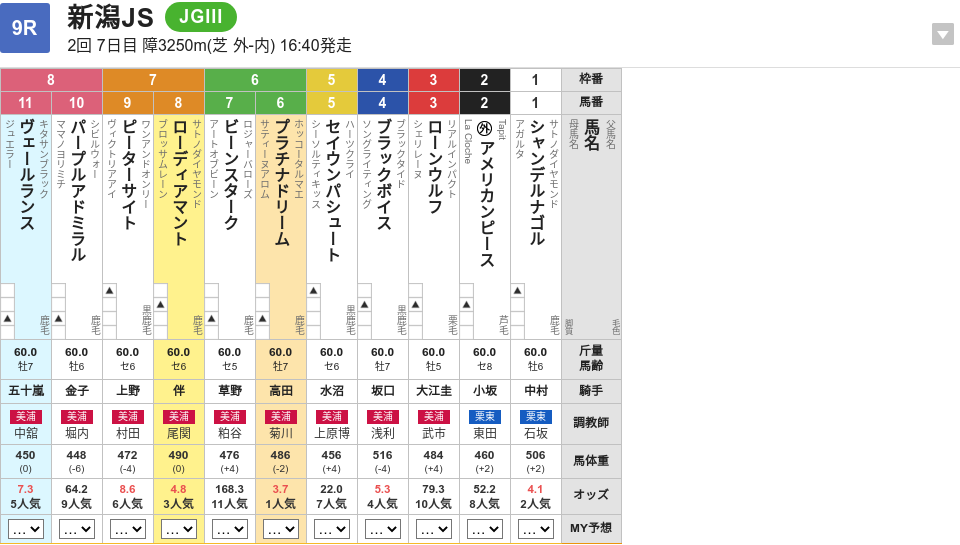

### 【中京記念 2026/08/16(日) 】

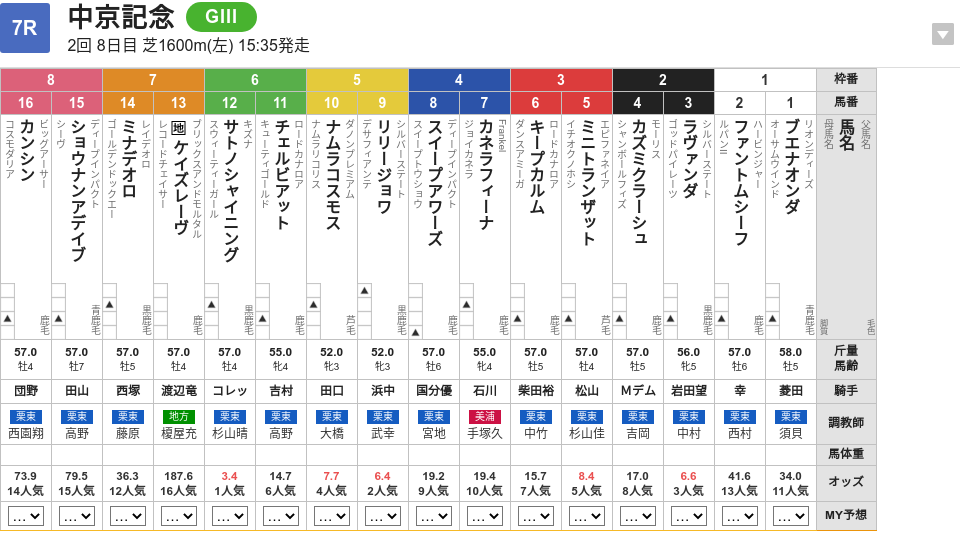

### 【札幌記念 2026/08/16(日) 】

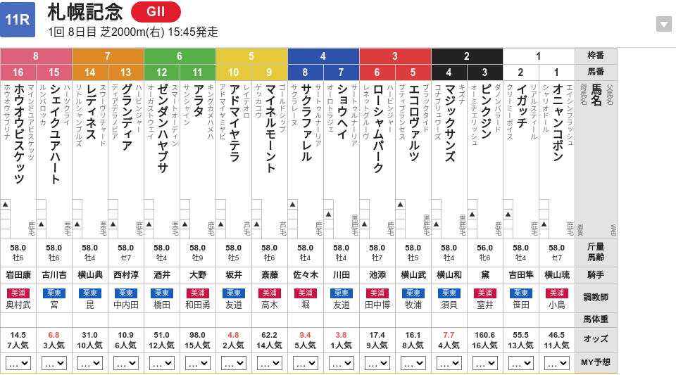

## 4. 単勝予測結果

### 【新潟ジャンプステークス(J.GⅢ) 2026/08/15(土)】

| 枠番 | 馬番 | 人気 | オッズ | 馬名 | 騎手 | 調教師 | 予測タイム(sec) | 1_順位 | 1-3着内確率(%) | 2_順位 | ﾀﾞｰｸﾎｰｽ確率(%) | 3_順位 |
| --- | --- | --- | --- | --- | --- | --- | --- | --- | --- | --- | --- | --- |
| 1 | 1 | 2 | 4.1 | シャンデルナゴル | 中村将之 | 石坂公一 | 209.1 | 1.5 | 28.1 | 1 | 0.6 | 10 |
| 2 | 2 | 8 | 52.2 | アメリカンピース | 小坂忠士 | 東田明士 | 225.2 | 7.0 | 2.5 | 8 | 21.3 | 1 |
| 3 | 3 | 10 | 79.3 | ローンウルフ | 大江原圭 | 武市康男 | 229.2 | 11.0 | 2.2 | 9 | 17.2 | 3 |
| 4 | 4 | 4 | 5.3 | ブラックボイス | 坂口智康 | 浅利英明 | 216.3 | 3.0 | 27.0 | 2 | 0.6 | 9 |
| 5 | 5 | 7 | 22.0 | セイウンパシュート | 水沼元輝 | 上原博之 | 225.4 | 8.0 | 2.6 | 7 | 18.5 | 2 |
| 6 | 6 | 1 | 3.7 | プラチナドリーム | 高田潤 | 菊川正達 | 209.1 | 1.5 | 14.3 | 6 | 0.6 | 11 |
| 6 | 7 | 11 | 168.3 | ビーンスターク | 草野太郎 | 粕谷昌央 | 228.5 | 10.0 | 1.6 | 11 | 12.6 | 4 |
| 7 | 8 | 3 | 4.8 | ローディアマント | 伴啓太 | 尾関知人 | 222.4 | 4.0 | 24.5 | 3 | 0.9 | 8 |
| 7 | 9 | 6 | 8.6 | ピーターサイト | 上野翔 | 村田一誠 | 222.4 | 5.0 | 18.7 | 5 | 0.9 | 6 |
| 8 | 10 | 9 | 64.2 | パープルアドミラル | 金子光希 | 堀内岳志 | 225.5 | 9.0 | 1.8 | 10 | 11.2 | 5 |

[output cut: 1 more lines]

### 【中京記念(GⅢ) 2026/08/16(日)】

| 枠番 | 馬番 | 人気 | オッズ | 馬名 | 騎手 | 調教師 | 予測タイム(sec) | 1_順位 | 1-3着内確率(%) | 2_順位 | ﾀﾞｰｸﾎｰｽ確率(%) | 3_順位 |
| --- | --- | --- | --- | --- | --- | --- | --- | --- | --- | --- | --- | --- |
| 1 | 1 | 11 | 33.3 | ブエナオンダ | 菱田裕二 | 須貝尚介 | 100.8 | 8 | 6.7 | 13 | 35.1 | 2 |
| 1 | 2 | 13 | 41.2 | ファントムシーフ | 幸英明 | 西村真幸 | 108.6 | 16 | 8.2 | 10 | 22.9 | 6 |
| 2 | 3 | 3 | 6.5 | ラヴァンダ | 岩田望来 | 中村直也 | 103.1 | 10 | 19.3 | 5 | 0.4 | 15 |
| 2 | 4 | 8 | 16.7 | カズミクラーシュ | Ｍ．デムーロ | 吉岡辰弥 | 101.3 | 9 | 7.4 | 12 | 1.3 | 10 |
| 3 | 5 | 5 | 8.6 | ミニトランザット | 松山弘平 | 杉山佳明 | 97.1 | 3 | 26.7 | 2 | 1.0 | 13 |
| 3 | 6 | 7 | 15.4 | キープカルム | 柴田裕一郎 | 中竹和也 | 99.3 | 7 | 13.7 | 7 | 1.7 | 9 |
| 4 | 7 | 10 | 18.9 | カネラフィーナ | 石川裕紀人 | 手塚貴久 | 97.4 | 4 | 15.6 | 6 | 34.3 | 4 |
| 4 | 8 | 9 | 18.8 | スイープアワーズ | 国分優作 | 宮地貴稔 | 107.4 | 15 | 9.6 | 8 | 13.5 | 7 |
| 5 | 9 | 2 | 6.3 | リリージョワ | 浜中俊 | 武幸四郎 | 98.5 | 6 | 45.8 | 1 | 0.4 | 14 |
| 5 | 10 | 4 | 7.7 | ナムラコスモス | 田口貫太 | 大橋勇樹 | 107.0 | 13 | 9.0 | 9 | 1.0 | 12 |

[output cut: 6 more lines]

### 【札幌記念(GⅡ) 2026/08/16(日)】

| 枠番 | 馬番 | 人気 | オッズ | 馬名 | 騎手 | 調教師 | 予測タイム(sec) | 1_順位 | 1-3着内確率(%) | 2_順位 | ﾀﾞｰｸﾎｰｽ確率(%) | 3_順位 |
| --- | --- | --- | --- | --- | --- | --- | --- | --- | --- | --- | --- | --- |
| 1 | 1 | 11 | 46.5 | オニャンコポン | 横山琉人 | 小島茂之 | 120.7 | 4.0 | 5.9 | 12 | 29.7 | 8 |
| 1 | 2 | 13 | 56.0 | イガッチ | 吉田隼人 | 笹田和秀 | 133.2 | 15.0 | 3.9 | 13 | 30.9 | 6 |
| 2 | 3 | 16 | 157.5 | ピンクジン | 黛弘人 | 室井潔 | 131.1 | 13.0 | 2.4 | 16 | 54.8 | 3 |
| 2 | 4 | 4 | 7.7 | マジックサンズ | 横山和生 | 須貝尚介 | 130.5 | 9.0 | 24.2 | 2 | 0.6 | 14 |
| 3 | 5 | 8 | 15.9 | エコロヴァルツ | 横山武史 | 牧浦充徳 | 128.7 | 6.0 | 11.8 | 9 | 1.8 | 9 |
| 3 | 6 | 9 | 17.3 | ローシャムパーク | 池添謙一 | 田中博康 | 118.7 | 2.0 | 18.5 | 5 | 60.8 | 2 |
| 4 | 7 | 1 | 3.9 | ショウヘイ | 川田将雅 | 友道康夫 | 118.7 | 2.0 | 24.4 | 1 | 0.6 | 15 |
| 4 | 8 | 5 | 9.3 | サクラファレル | 佐々木大輔 | 堀宣行 | 131.0 | 11.5 | 19.0 | 4 | 1.1 | 11 |
| 5 | 9 | 14 | 63.0 | マイネルモーント | 斎藤新 | 高木登 | 129.2 | 7.0 | 6.8 | 11 | 68.4 | 1 |
| 5 | 10 | 2 | 4.8 | アドマイヤテラ | 坂井瑠星 | 友道康夫 | 131.0 | 10.0 | 23.6 | 3 | 0.6 | 13 |

[output cut: 6 more lines]

## 5. 人気と着順の乖離率推移

### 【新潟ジャンプステークス_1999y_2019y】

[interactive chart not shown]

### 【中京記念_1990y_2019y】

[interactive chart not shown]

### 【札幌記念_1990y_2019y】

[interactive chart not shown]

### 【新潟ジャンプステークス_1999y_2019y】

| No | 開催年 | 不整合率(%) | 頭数 | 人気別着順(1-3位) | 人気別着順(全体) |
| --- | --- | --- | --- | --- | --- |
| 21 | 2019 | 36.8 | 11頭 | 3-1-6 | 3\|1\|6\|2\|7\|4\|8\|11\|10\|9\|5 |
| 20 | 2018 | 43.5 | 12頭 | 2-8-7 | 2\|8\|7\|5\|1\|6\|11\|9\|10\|12\|4\|13 |
| 19 | 2017 | 47.9 | 11頭 | 3-2-8 | 3\|2\|8\|1\|7\|4\|11\|5\|6\|10\|9 |
| 18 | 2016 | 57.1 | 14頭 | 3-2-10 | 3\|2\|10\|7\|8\|5\|6\|1\|14\|9\|12\|13\|4\|11 |
| 17 | 2015 | 32.0 | 14頭 | 8-2-1 | 8\|2\|1\|5\|4\|7\|3\|6\|10\|9\|12\|13\|14\|11 |
| 16 | 2014 | 23.5 | 12頭 | 1-4-8 | 1\|4\|8\|2\|5\|7\|6\|3\|12\|10\|9\|11 |
| 15 | 2013 | 37.5 | 14頭 | 3-1-10 | 3\|1\|10\|5\|2\|14\|4\|8\|9\|11\|12\|7\|13\|6 |
| 14 | 2012 | 46.4 | 13頭 | 3-2-4 | 3\|2\|4\|1\|6\|7\|5\|10\|11\|13\|8\|14\|12 |
| 13 | 2011 | 47.8 | 14頭 | 3-2-1 | 3\|2\|1\|10\|12\|6\|9\|11\|4\|13\|8\|14\|5\|7 |
| 12 | 2010 | 26.1 | 14頭 | 1-12-4 | 1\|12\|4\|2\|8\|5\|9\|7\|10\|13\|6\|11\|3\|14 |

[output cut: 11 more lines]

### 【中京記念_1990y_2019y】

| No | 開催年 | 不整合率(%) | 頭数 | 人気別着順(1-3位) | 人気別着順(全体) |
| --- | --- | --- | --- | --- | --- |
| 30 | 2019 | 42.7 | 16頭 | 3-6-1 | 3\|6\|1\|4\|9\|11\|8\|2\|7\|10\|5\|14\|15\|13\|16\|12 |
| 29 | 2018 | 38.8 | 16頭 | 1-5-4 | 1\|5\|4\|7\|3\|13\|6\|2\|15\|10\|11\|9\|12\|14\|8\|16 |
| 28 | 2017 | 35.3 | 16頭 | 5-2-1 | 5\|2\|1\|4\|3\|16\|14\|15\|11\|7\|13\|8\|10\|12\|9\|6 |
| 27 | 2016 | 48.2 | 16頭 | 7-6-4 | 7\|6\|4\|16\|5\|10\|14\|11\|9\|1\|15\|2\|13\|12\|3\|8 |
| 26 | 2015 | 48.2 | 16頭 | 6-13-3 | 6\|13\|3\|15\|8\|7\|1\|2\|16\|10\|12\|5\|11\|14\|4\|9 |
| 25 | 2014 | 65.7 | 16頭 | 7-11-5 | 7\|11\|5\|6\|10\|16\|3\|2\|15\|1\|4\|9\|13\|8\|14\|12 |
| 24 | 2013 | 63.6 | 15頭 | 5-13-3 | 5\|13\|3\|2\|6\|9\|12\|10\|8\|1\|16\|14\|15\|11\|7 |
| 23 | 2012 | 53.7 | 16頭 | 5-6-10 | 5\|6\|10\|7\|9\|3\|1\|15\|13\|14\|2\|16\|12\|4\|8\|11 |
| 22 | 2011 | 52.2 | 16頭 | 2-8-12 | 2\|8\|12\|10\|3\|15\|14\|6\|9\|11\|13\|7\|5\|16\|1\|4 |
| 21 | 2010 | 59.0 | 18頭 | 4-12-15 | 4\|12\|15\|11\|7\|3\|5\|1\|10\|9\|6\|17\|18\|2\|16\|8\|14\|13 |

[output cut: 20 more lines]

### 【札幌記念_1990y_2019y】

| No | 開催年 | 不整合率(%) | 頭数 | 人気別着順(1-3位) | 人気別着順(全体) |
| --- | --- | --- | --- | --- | --- |
| 30 | 2019 | 38.3 | 14頭 | 3-4-1 | 3\|4\|1\|2\|5\|11\|6\|9\|8\|10\|13\|14\|12\|7 |
| 29 | 2018 | 32.4 | 16頭 | 2-1-4 | 2\|1\|4\|13\|12\|7\|8\|11\|6\|15\|14\|10\|3\|5\|9\|16 |
| 28 | 2017 | 27.6 | 13頭 | 6-12-1 | 6\|12\|1\|4\|2\|5\|9\|3\|7\|13\|11\|10\|8 |
| 27 | 2016 | 26.0 | 16頭 | 5-1-4 | 5\|1\|4\|2\|3\|12\|14\|15\|11\|6\|16\|7\|8\|13\|9\|10 |
| 26 | 2015 | 60.6 | 15頭 | 5-8-4 | 5\|8\|4\|10\|2\|3\|7\|1\|6\|11\|12\|14\|13\|9\|15 |
| 25 | 2014 | 36.7 | 14頭 | 2-1-7 | 2\|1\|7\|6\|5\|13\|12\|4\|8\|9\|3\|14\|10\|11 |
| 24 | 2013 | 42.4 | 16頭 | 2-8-14 | 2\|8\|14\|6\|1\|11\|5\|7\|12\|15\|10\|16\|4\|9\|3\|13 |
| 23 | 2012 | 28.4 | 14頭 | 4-1-2 | 4\|1\|2\|5\|9\|11\|8\|6\|10\|13\|3\|14\|12\|7 |
| 22 | 2011 | 28.6 | 13頭 | 1-5-2 | 1\|5\|2\|8\|7\|9\|6\|12\|10\|4\|11\|3\|13 |
| 21 | 2010 | 21.1 | 16頭 | 1-5-7 | 1\|5\|7\|2\|4\|3\|6\|16\|11\|14\|13\|8\|10\|9\|12\|15 |

[output cut: 20 more lines]

## 6. 1-3番人気馬の着順分類予測

### 【新潟ジャンプステークス】

| 分類 | 凡例 | 発生確率(%) | 当該レース | 当該レースランク | 直近1年間 |
| --- | --- | --- | --- | --- | --- |
| 1: 1番人気のみ (1_pop1) | 1 \| * \| * | 18.3 | 1.24 | 0.91 | 0.00 |
| 4: 1,2番人気のみ (4_pop12) | 1 \| 2 \| * | 17.4 | 2.35 | 4.05 | 0.00 |
| 5: 1,3番人気のみ (5_pop13) | 1 \| 3 \| * | 17.1 | 0.51 | 0.67 | 0.17 |
| 8: 1,2,3番人気すべて着外 (8_darkhorse) | * \| * \| * | 13.7 | 0.93 | 0.64 | 0.00 |
| 6: 2,3番人気のみ (6_pop23) | 2 \| 3 \| * | 9.7 | 0.52 | 0.97 | 0.00 |
| 2: 2番人気のみ (2_pop2) | 2 \| * \| * | 9.0 | 1.22 | 0.90 | 0.00 |
| 3: 3番人気のみ (3_pop3) | 3 \| * \| * | 8.0 | 0.00 | 1.13 | 0.00 |
| 7: 1,2,3番人気すべて着内 (7_pop123) | 1 \| 2 \| 3 | 6.8 | 1.84 | 4.86 | 0.00 |

### 【中京記念】

| 分類 | 凡例 | 発生確率(%) | 当該レース | 当該レースランク | 直近1年間 |
| --- | --- | --- | --- | --- | --- |
| 1: 1番人気のみ (1_pop1) | 1 \| * \| * | 18.3 | 0.94 | 0.79 | 0.00 |
| 4: 1,2番人気のみ (4_pop12) | 1 \| 2 \| * | 17.4 | 6.21 | 7.57 | 0.00 |
| 5: 1,3番人気のみ (5_pop13) | 1 \| 3 \| * | 17.1 | 0.68 | 0.82 | 0.17 |
| 8: 1,2,3番人気すべて着外 (8_darkhorse) | * \| * \| * | 13.7 | 0.62 | 0.54 | 0.00 |
| 6: 2,3番人気のみ (6_pop23) | 2 \| 3 \| * | 9.7 | 1.73 | 2.06 | 0.00 |
| 2: 2番人気のみ (2_pop2) | 2 \| * \| * | 9.0 | 0.81 | 0.78 | 0.00 |
| 3: 3番人気のみ (3_pop3) | 3 \| * \| * | 8.0 | 0.58 | 0.69 | 0.00 |
| 7: 1,2,3番人気すべて着内 (7_pop123) | 1 \| 2 \| 3 | 6.8 | 0.00 | 0.00 | 0.00 |

### 【札幌記念】

| 分類 | 凡例 | 発生確率(%) | 当該レース | 当該レースランク | 直近1年間 |
| --- | --- | --- | --- | --- | --- |
| 1: 1番人気のみ (1_pop1) | 1 \| * \| * | 18.2 | 0.94 | 0.78 | 0.00 |
| 4: 1,2番人気のみ (4_pop12) | 1 \| 2 \| * | 17.6 | 0.70 | 7.65 | 0.00 |
| 5: 1,3番人気のみ (5_pop13) | 1 \| 3 \| * | 16.3 | 0.65 | 0.78 | 0.16 |
| 8: 1,2,3番人気すべて着外 (8_darkhorse) | * \| * \| * | 13.8 | 0.99 | 0.54 | 0.00 |
| 6: 2,3番人気のみ (6_pop23) | 2 \| 3 \| * | 9.9 | 0.00 | 2.11 | 0.00 |
| 2: 2番人気のみ (2_pop2) | 2 \| * \| * | 9.1 | 1.10 | 0.78 | 0.00 |
| 3: 3番人気のみ (3_pop3) | 3 \| * \| * | 8.2 | 2.93 | 0.71 | 0.00 |
| 7: 1,2,3番人気すべて着内 (7_pop123) | 1 \| 2 \| 3 | 6.9 | 1.23 | 0.00 | 0.00 |

## 7. 3連複予測結果

### 【新潟ジャンプステークス(J.GⅢ) 2026/08/15(土)】

| 分類 | 馬番 | 枠番 | 人気 | 平均予測タイム(sec) | 1-3着内確率(%) | ﾀﾞｰｸﾎｰｽ確率(%) | 馬名 | 騎手 | 調教師 |
| --- | --- | --- | --- | --- | --- | --- | --- | --- | --- |
| 6: 2,3番人気のみ (6_pop23) | 1-8-4 | 1-7-4 | 2-3-4 | 215.93 | 1.86 | 0.00 | シャンデルナゴル \| ローディアマント \| ブラックボイス | 中村将之 \| 伴啓太 \| 坂口智康 | 石坂公一 \| 尾関知人 \| 浅利英明 |
| 2: 2番人気のみ (2_pop2) | 1-4-11 | 1-4-8 | 2-4-5 | 216.03 | 1.55 | 0.00 | シャンデルナゴル \| ブラックボイス \| ヴェールランス | 中村将之 \| 坂口智康 \| 五十嵐雄祐 | 石坂公一 \| 浅利英明 \| 中舘英二 |
| 2: 2番人気のみ (2_pop2) | 1-4-9 | 1-4-7 | 2-4-6 | 215.93 | 1.42 | 0.00 | シャンデルナゴル \| ブラックボイス \| ピーターサイト | 中村将之 \| 坂口智康 \| 上野翔 | 石坂公一 \| 浅利英明 \| 村田一誠 |
| 6: 2,3番人気のみ (6_pop23) | 1-8-11 | 1-7-8 | 2-3-5 | 218.07 | 1.41 | 0.00 | シャンデルナゴル \| ローディアマント \| ヴェールランス | 中村将之 \| 伴啓太 \| 五十嵐雄祐 | 石坂公一 \| 尾関知人 \| 中舘英二 |
| 3: 3番人気のみ (3_pop3) | 8-4-11 | 7-4-8 | 3-4-5 | 220.47 | 1.35 | 0.00 | ローディアマント \| ブラックボイス \| ヴェールランス | 伴啓太 \| 坂口智康 \| 五十嵐雄祐 | 尾関知人 \| 浅利英明 \| 中舘英二 |
| 6: 2,3番人気のみ (6_pop23) | 1-8-9 | 1-7-7 | 2-3-6 | 217.97 | 1.29 | 0.00 | シャンデルナゴル \| ローディアマント \| ピーターサイト | 中村将之 \| 伴啓太 \| 上野翔 | 石坂公一 \| 尾関知人 \| 村田一誠 |
| 3: 3番人気のみ (3_pop3) | 8-4-9 | 7-4-7 | 3-4-6 | 220.37 | 1.23 | 0.00 | ローディアマント \| ブラックボイス \| ピーターサイト | 伴啓太 \| 坂口智康 \| 上野翔 | 尾関知人 \| 浅利英明 \| 村田一誠 |
| 4: 1,2番人気のみ (4_pop12) | 6-1-4 | 6-1-4 | 1-2-4 | 211.50 | 1.09 | 0.00 | プラチナドリーム \| シャンデルナゴル \| ブラックボイス | 高田潤 \| 中村将之 \| 坂口智康 | 菊川正達 \| 石坂公一 \| 浅利英明 |
| 2: 2番人気のみ (2_pop2) | 1-11-9 | 1-8-7 | 2-5-6 | 218.07 | 1.07 | 0.00 | シャンデルナゴル \| ヴェールランス \| ピーターサイト | 中村将之 \| 五十嵐雄祐 \| 上野翔 | 石坂公一 \| 中舘英二 \| 村田一誠 |
| 8: 1,2,3番人気すべて着外 (8_darkhorse) | 4-11-9 | 4-8-7 | 4-5-6 | 220.47 | 1.03 | 0.00 | ブラックボイス \| ヴェールランス \| ピーターサイト | 坂口智康 \| 五十嵐雄祐 \| 上野翔 | 浅利英明 \| 中舘英二 \| 村田一誠 |

[output cut: 155 more lines]

### 【中京記念(GⅢ) 2026/08/16(日)】

| 分類 | 馬番 | 枠番 | 人気 | 平均予測タイム(sec) | 1-3着内確率(%) | ﾀﾞｰｸﾎｰｽ確率(%) | 馬名 | 騎手 | 調教師 |
| --- | --- | --- | --- | --- | --- | --- | --- | --- | --- |
| 4: 1,2番人気のみ (4_pop12) | 12-9-5 | 6-5-3 | 1-2-5 | 95.97 | 2.81 | 0.00 | サトノシャイニング \| リリージョワ \| ミニトランザット | Ｊ．コレット \| 浜中俊 \| 松山弘平 | 杉山晴紀 \| 武幸四郎 \| 杉山佳明 |
| 2: 2番人気のみ (2_pop2) | 9-5-11 | 5-3-6 | 2-5-6 | 97.73 | 2.56 | 0.00 | リリージョワ \| ミニトランザット \| チェルビアット | 浜中俊 \| 松山弘平 \| 吉村誠之助 | 武幸四郎 \| 杉山佳明 \| 高野友和 |
| 6: 2,3番人気のみ (6_pop23) | 9-3-5 | 5-2-3 | 2-3-5 | 99.57 | 2.36 | 0.00 | リリージョワ \| ラヴァンダ \| ミニトランザット | 浜中俊 \| 岩田望来 \| 松山弘平 | 武幸四郎 \| 中村直也 \| 杉山佳明 |
| 4: 1,2番人気のみ (4_pop12) | 12-9-11 | 6-5-6 | 1-2-6 | 96.13 | 2.20 | 0.00 | サトノシャイニング \| リリージョワ \| チェルビアット | Ｊ．コレット \| 浜中俊 \| 吉村誠之助 | 杉山晴紀 \| 武幸四郎 \| 高野友和 |
| 7: 1,2,3番人気すべて着内 (7_pop123) | 12-9-3 | 6-5-2 | 1-2-3 | 97.97 | 2.03 | 0.00 | サトノシャイニング \| リリージョワ \| ラヴァンダ | Ｊ．コレット \| 浜中俊 \| 岩田望来 | 杉山晴紀 \| 武幸四郎 \| 中村直也 |
| 2: 2番人気のみ (2_pop2) | 9-5-7 | 5-3-4 | 2-5-10 | 97.67 | 1.91 | 0.00 | リリージョワ \| ミニトランザット \| カネラフィーナ | 浜中俊 \| 松山弘平 \| 石川裕紀人 | 武幸四郎 \| 杉山佳明 \| 手塚貴久 |
| 6: 2,3番人気のみ (6_pop23) | 9-3-11 | 5-2-6 | 2-3-6 | 99.73 | 1.85 | 0.00 | リリージョワ \| ラヴァンダ \| チェルビアット | 浜中俊 \| 岩田望来 \| 吉村誠之助 | 武幸四郎 \| 中村直也 \| 高野友和 |
| 2: 2番人気のみ (2_pop2) | 9-5-6 | 5-3-3 | 2-5-7 | 98.30 | 1.67 | 0.00 | リリージョワ \| ミニトランザット \| キープカルム | 浜中俊 \| 松山弘平 \| 柴田裕一郎 | 武幸四郎 \| 杉山佳明 \| 中竹和也 |
| 4: 1,2番人気のみ (4_pop12) | 12-9-7 | 6-5-4 | 1-2-10 | 96.07 | 1.65 | 0.00 | サトノシャイニング \| リリージョワ \| カネラフィーナ | Ｊ．コレット \| 浜中俊 \| 石川裕紀人 | 杉山晴紀 \| 武幸四郎 \| 手塚貴久 |
| 2: 2番人気のみ (2_pop2) | 9-11-7 | 5-6-4 | 2-6-10 | 97.83 | 1.50 | 0.00 | リリージョワ \| チェルビアット \| カネラフィーナ | 浜中俊 \| 吉村誠之助 \| 石川裕紀人 | 武幸四郎 \| 高野友和 \| 手塚貴久 |

[output cut: 550 more lines]

### 【札幌記念(GⅡ) 2026/08/16(日)】

| 分類 | 馬番 | 枠番 | 人気 | 平均予測タイム(sec) | 1-3着内確率(%) | ﾀﾞｰｸﾎｰｽ確率(%) | 馬名 | 騎手 | 調教師 |
| --- | --- | --- | --- | --- | --- | --- | --- | --- | --- |
| 4: 1,2番人気のみ (4_pop12) | 7-10-4 | 4-5-2 | 1-2-4 | 126.73 | 1.39 | 0.00 | ショウヘイ \| アドマイヤテラ \| マジックサンズ | 川田将雅 \| 坂井瑠星 \| 横山和生 | 友道康夫 \| 友道康夫 \| 須貝尚介 |
| 1: 1番人気のみ (1_pop1) | 7-4-8 | 4-2-4 | 1-4-5 | 126.73 | 1.12 | 0.00 | ショウヘイ \| マジックサンズ \| サクラファレル | 川田将雅 \| 横山和生 \| 佐々木大輔 | 友道康夫 \| 須貝尚介 \| 堀宣行 |
| 1: 1番人気のみ (1_pop1) | 7-4-6 | 4-2-3 | 1-4-9 | 122.63 | 1.09 | 0.00 | ショウヘイ \| マジックサンズ \| ローシャムパーク | 川田将雅 \| 横山和生 \| 池添謙一 | 友道康夫 \| 須貝尚介 \| 田中博康 |
| 4: 1,2番人気のみ (4_pop12) | 7-10-8 | 4-5-4 | 1-2-5 | 126.90 | 1.09 | 0.00 | ショウヘイ \| アドマイヤテラ \| サクラファレル | 川田将雅 \| 坂井瑠星 \| 佐々木大輔 | 友道康夫 \| 友道康夫 \| 堀宣行 |
| 2: 2番人気のみ (2_pop2) | 10-4-8 | 5-2-4 | 2-4-5 | 130.83 | 1.08 | 0.00 | アドマイヤテラ \| マジックサンズ \| サクラファレル | 坂井瑠星 \| 横山和生 \| 佐々木大輔 | 友道康夫 \| 須貝尚介 \| 堀宣行 |
| 4: 1,2番人気のみ (4_pop12) | 7-10-6 | 4-5-3 | 1-2-9 | 122.80 | 1.07 | 0.00 | ショウヘイ \| アドマイヤテラ \| ローシャムパーク | 川田将雅 \| 坂井瑠星 \| 池添謙一 | 友道康夫 \| 友道康夫 \| 田中博康 |
| 2: 2番人気のみ (2_pop2) | 10-4-6 | 5-2-3 | 2-4-9 | 126.73 | 1.06 | 0.00 | アドマイヤテラ \| マジックサンズ \| ローシャムパーク | 坂井瑠星 \| 横山和生 \| 池添謙一 | 友道康夫 \| 須貝尚介 \| 田中博康 |
| 1: 1番人気のみ (1_pop1) | 7-4-16 | 4-2-8 | 1-4-7 | 126.33 | 0.91 | 0.00 | ショウヘイ \| マジックサンズ \| ホウオウビスケッツ | 川田将雅 \| 横山和生 \| 岩田康誠 | 友道康夫 \| 須貝尚介 \| 奥村武 |
| 4: 1,2番人気のみ (4_pop12) | 7-10-16 | 4-5-8 | 1-2-7 | 126.50 | 0.89 | 0.00 | ショウヘイ \| アドマイヤテラ \| ホウオウビスケッツ | 川田将雅 \| 坂井瑠星 \| 岩田康誠 | 友道康夫 \| 友道康夫 \| 奥村武 |
| 2: 2番人気のみ (2_pop2) | 10-4-16 | 5-2-8 | 2-4-7 | 130.43 | 0.88 | 0.00 | アドマイヤテラ \| マジックサンズ \| ホウオウビスケッツ | 坂井瑠星 \| 横山和生 \| 岩田康誠 | 友道康夫 \| 須貝尚介 \| 奥村武 |

[output cut: 550 more lines]

## 8. 直近の全レース情報

[output not shown]